# HLM

Marcos H Silva

24/04/2022

# Modelo de regressão multinível

### Uma rápida introdução

O texto de hoje é sobre uma outra forma de criar um modelo capaz de “prever” um resultado baseado em dados. Meus últimos dois textos abordaram formas de criar redes neurais e como usá-las para prever resultados: [Rede neural recorrente para identificação de dígitos](https://www.linkedin.com/pulse/rede-neural-recorrente-para-identifica%C3%A7%C3%A3o-de-d%C3%ADgitos-marcos-silva/) e [Rede LSTM para predição da cotação do dólar](https://rpubs.com/marcosmhs/rede_lstm_predicao_dolar).

Hoje trago uma outra abordagem, tão importante quanto as redes neurais e capaz de criar resultados mais claros!

Imagine que você gostaria de avaliar qual seria o resultado de sua empresa usando por exemplo a nota do NPS que suas lojas (ou loja) recebeu. Para lhe ajudar com este cálculo você possui uma base de dados com registros históricos, acumulando as vendas dos últimos 12 meses e das notas que as lojas registraram.

Se colocarmos estes dados em um gráfico do excel com receita no eixo X e NPS no eixo Y, teremos o seguinte resultado:

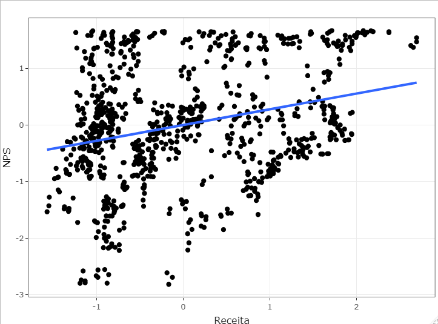

Cada ponto preto representa o cruzamento de resultado e NPS de uma loja e a linha azul é a reta de regressão, uma linha que tenta passar o mais próximo possível de todos os pontos, numa tentativa de resumir o gráfico a uma só informação.

Um modelo de regressão tenta estimar qual seria a reta para dados que não estão em sua base, usando apenas as informações existentes. **Por exemplo, qual será a receita de uma loja se ela tiver uma nota NPS 87,8?**

A fórmula base para explicar um modelo de regressão linear com base neste exemplo seria:

$$Y = \gamma_0 + NPS_1 * \gamma_1 + \epsilon$$

Onde :

- $\gamma_0$(gama 0) representa uma a média da variável resposta
- $\gamma_1$ (gama 1) representa a participação do NPS na inclinação da reta de regressão
- $\epsilon$ (epsilon) representa a distância entre o valor real da receita e o valor que foi previsto pelos termos $\gamma_1$, este valor também é chamado de erro ou resíduo

O desafio neste tipo de modelo é encontrar os valores de $\gamma_0$ e $\gamma_1$para que possamos substituí-los em nossa fórmula e encontrar o valor da receita.

### E quando o mundo não é linear? E quase sempre não é!

A modelagem linear cumpre bem o seu papel em determinados cenários, mas em muitos casos ela sozinha não é suficiente para explicar um mundo tão diverso. **E é ai que entra a modelagem multinível**! Um modelo que prevê que o mundo é feito de grupos e que estes grupos exercem influência sobre os dados. Este modelo considera que os dados podem ser agrupados em até três níveis:

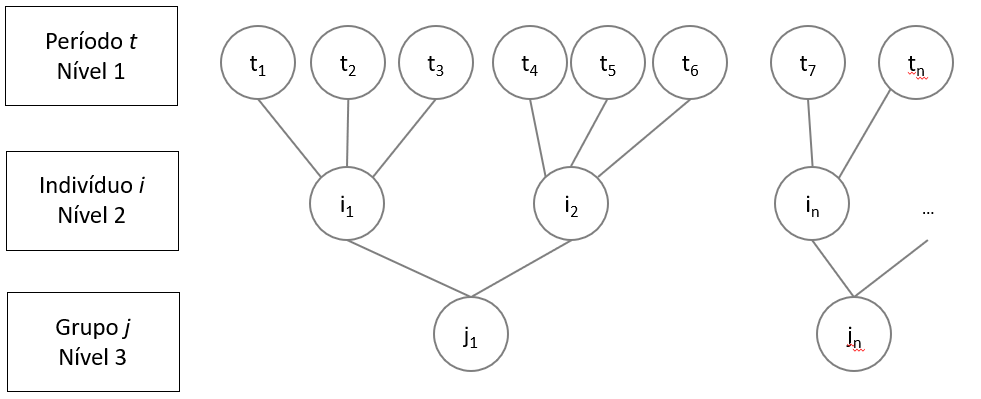

Onde:

- Grupo 1 (*t*), podemos trabalhar com uma escala de tempo, por exemplo, se houver dados de minha loja segmentados por mês;
- Grupo 2 (*i*), temos o indivíduo, no nosso exemplo a loja;
- Grupo 3 (*j*) temos o agrupamento, neste caso a cidade.

Neste cenário podemos avaliar que as lojas podem ter comportamento diferente dependendo da cidade onde estão localizadas e que variáveis específicas destas cidades podem influenciar em seu resultado, além do NPS.

Neste caso trabalharemos com os grupos *i* e *j* apenas, respectivamente os níveis 1 (loja) e 2 (cidade).

### Preparação dos pacotes

```r
pacotes = c("plotly","tidyverse","reshape2","knitr","kableExtra","rgl","car", "nlme","lmtest","fastDummies","msm","lmeInfo","jtools", "data.table", "olsrr")

if(sum(as.numeric(!pacotes %in% installed.packages())) != 0){
  instalador <- pacotes[!pacotes %in% installed.packages()]
  for(i in 1:length(instalador)) {
    install.packages(instalador, dependencies = T)
    break()}
  sapply(pacotes, require, character = T)
} else {
  sapply(pacotes, require, character = T)
}
```

```
##      plotly   tidyverse    reshape2       knitr  kableExtra         rgl
##        TRUE        TRUE        TRUE        TRUE        TRUE        TRUE
##         car        nlme      lmtest fastDummies         msm     lmeInfo
##        TRUE        TRUE        TRUE        TRUE        TRUE        TRUE
##      jtools  data.table       olsrr
##        TRUE        TRUE        TRUE
```

A função `stderr_nlme`, de autoria dos professores Fávero e Rafael Sousa ajuda a identificar a significância estatística dos dados de cada nível e de certa forma a calcular o quanto do comportamento dos dados é explicado por cada nível.

```r
stderr_nlme <- function(model){
  if(base::class(model) != "lme"){
    base::message("Use a lme object model from nlme package")
    stop()}
  resume <- base::summary(model)
  if(base::length(base::names(model$groups))==1){
    m.type <- "HLM2"
  } else if(base::length(base::names(model$groups))==2){
    m.type <- "HLM3"
  }
  if(m.type == "HLM2"){
    vcov_matrix <- model$apVar
    logs_sd_re <- base::attr(vcov_matrix,"Pars")
    if(base::length(logs_sd_re)==2){
      stderr_tau00 <- msm::deltamethod(~exp(x1)^2,logs_sd_re,vcov_matrix)
      stderr_sigma <- msm::deltamethod(~exp(x2)^2,logs_sd_re,vcov_matrix)
      results <- base::data.frame(`RE Components`=base::c("Var(v0j)","Var(e)"),
                                  `Variance Estimatives`= base::c(base::exp(logs_sd_re)[[1]]^2,
                                                                  base::exp(logs_sd_re[[2]])^2),
                                  `Std Err.`=base::c(stderr_tau00,
                                                     stderr_sigma),
                                  z=base::c(base::exp(logs_sd_re)[[1]]^2/stderr_tau00,
                                            base::exp(logs_sd_re[[2]])^2/stderr_sigma),
                                  `p-value`=base::round(stats::pnorm(q=base::c(base::exp(logs_sd_re)[[1]]^2/stderr_tau00,
                                                                               base::exp(logs_sd_re[[2]])^2/stderr_sigma),
                                                                     lower.tail=F)*2,3))
      return(results)
    }
    else{
      stderr_tau00 <- msm::deltamethod(~exp(x1)^2,logs_sd_re,vcov_matrix)
      stderr_tau01 <- msm::deltamethod(~exp(x2)^2,logs_sd_re,vcov_matrix)
      stderr_sigma <- msm::deltamethod(~exp(x4)^2,logs_sd_re,vcov_matrix)
      results <- base::data.frame(Components=base::c("Var(v0j)","Var(v1j)","Var(e)"),
                                  `Variance Estimatives`= base::c(base::exp(logs_sd_re)[[1]]^2,
                                                       base::exp(logs_sd_re[[2]])^2,
                                                       base::exp(logs_sd_re[[4]])^2),
                                  `Std Err.`=base::c(stderr_tau00,
                                                  stderr_tau01,
                                                  stderr_sigma),
                                  z=base::c(base::exp(logs_sd_re)[[1]]^2/stderr_tau00,
                                            base::exp(logs_sd_re[[2]])^2/stderr_tau01,
                                            base::exp(logs_sd_re[[4]])^2/stderr_sigma),
                                  `p-value`=base::round(stats::pnorm(q=base::c(base::exp(logs_sd_re)[[1]]^2/stderr_tau00,
                                                                               base::exp(logs_sd_re[[2]])^2/stderr_tau01,
                                                                               base::exp(logs_sd_re[[4]])^2/stderr_sigma),
                                                                     lower.tail=F)*2,3))
      return(results)
    }
  }
  if(m.type == "HLM3"){
    vcov_matrix <- model$apVar
    logs_sd_re <-  base::attr(vcov_matrix,"Pars")
    if(base::length(logs_sd_re) == 3){
      stderr_tau_r000 <- msm::deltamethod(~exp(x1)^2,logs_sd_re,vcov_matrix)
      stderr_tau_u000 <- msm::deltamethod(~exp(x2)^2,logs_sd_re,vcov_matrix)
      stderr_sigma <- msm::deltamethod(~exp(x3)^2,logs_sd_re,vcov_matrix)
      results <- base::data.frame(Components=base::c("Var(t00k)","Var(v0jk)","Var(e)"),
                                  Estimatives=base::c(base::exp(logs_sd_re)[[2]]^2,
                                                      base::exp(logs_sd_re)[[1]]^2,
                                                      base::exp(logs_sd_re)[[3]]^2),
                                  Std_Err=base::c(stderr_tau_u000,
                                                  stderr_tau_r000,
                                                  stderr_sigma),
                                  z=base::c(base::exp(logs_sd_re)[[2]]^2/stderr_tau_u000,
                                            base::exp(logs_sd_re)[[1]]^2/stderr_tau_r000,
                                            base::exp(logs_sd_re)[[3]]^2/stderr_sigma),
                                  `p-value`=base::round(stats::pnorm(q=base::c(base::exp(logs_sd_re)[[2]]^2/stderr_tau_u000,
                                                                               base::exp(logs_sd_re)[[1]]^2/stderr_tau_r000,
                                                                               base::exp(logs_sd_re)[[3]]^2/stderr_sigma),
                                                                     lower.tail=F)*2,3))
      return(results)
    }
    else{
      stderr_tau_r000 <- msm::deltamethod(~exp(x1)^2,logs_sd_re,vcov_matrix)
      stderr_tau_r100 <- msm::deltamethod(~exp(x2)^2,logs_sd_re,vcov_matrix)
      stderr_tau_u000 <- msm::deltamethod(~exp(x4)^2,logs_sd_re,vcov_matrix)
      stderr_tau_u100 <- msm::deltamethod(~exp(x5)^2,logs_sd_re,vcov_matrix)
      stderr_sigma <- msm::deltamethod(~exp(x7)^2,logs_sd_re,vcov_matrix)
      results <- base::data.frame(`RE_Components`=base::c("Var(t00k)","Var(t10k)",
                                                          "Var(v0jk)","Var(v1jk)",
                                                          "Var(e)"),
                                  `Variance Estimatives`=base::c(base::exp(logs_sd_re)[[4]]^2,
                                                                 base::exp(logs_sd_re)[[5]]^2,
                                                                 base::exp(logs_sd_re)[[1]]^2,
                                                                 base::exp(logs_sd_re)[[2]]^2,
                                                                 base::exp(logs_sd_re)[[7]]^2),
                                  `Std Err.`=base::c(stderr_tau_u000,
                                                     stderr_tau_u100,
                                                     stderr_tau_r000,
                                                     stderr_tau_r100,
                                                     stderr_sigma),
                                  z=base::c(base::exp(logs_sd_re)[[4]]^2/stderr_tau_u000,
                                            base::exp(logs_sd_re)[[5]]^2/stderr_tau_u100,
                                            base::exp(logs_sd_re)[[1]]^2/stderr_tau_r000,
                                            base::exp(logs_sd_re)[[2]]^2/stderr_tau_r100,
                                            base::exp(logs_sd_re)[[7]]^2/stderr_sigma),
                                  `p-value`=base::round(stats::pnorm(q=base::c(base::exp(logs_sd_re)[[4]]^2/stderr_tau_u000,
                                                                               base::exp(logs_sd_re)[[5]]^2/stderr_tau_u100,
                                                                               base::exp(logs_sd_re)[[1]]^2/stderr_tau_r000,
                                                                               base::exp(logs_sd_re)[[2]]^2/stderr_tau_r100,
                                                                               base::exp(logs_sd_re)[[7]]^2/stderr_sigma),
                                                                     lower.tail=F)*2,3))
      return(results)
    }
  }
}
```

### Importação dos dados e análise exploratória

```r
vendas =
  fread("dados_vendas_totais_2021.csv", dec =",", sep=";") %>%
  select(cidade, loja, receita, nps, inflacao) %>%
  mutate(loja = as.factor(loja), cidade = as.factor(cidade))
```

Para testar o modelo vamos utilizar uma segunda base de dados semelhante à nossa base de treino (vendas) com 195 registros

```r
teste =
  fread("dados_para_teste.csv", dec =",", sep=";") %>%
  select(cidade, loja, receita, nps, inflacao) %>%
  mutate(loja = as.factor(loja), cidade = as.factor(cidade))
```

```r
rbind(
  vendas %>%

    filter(cidade == 1) %>%
    filter(row_number() <= 5),
  vendas %>%

    filter(cidade == 2) %>%
    filter(row_number() <= 5)) %>%

  kable() %>%
  kable_styling(bootstrap_options = "striped",
                position = "center",
                full_width = F,
                font_size = 14)
```

| cidade | loja | receita | nps | inflacao |
| --- | --- | --- | --- | --- |
| 1 | 1 | 1137.5282 | 58.78 | 0.1031 |
| 1 | 2 | 2278.7025 | 85.45 | 0.1031 |
| 1 | 3 | 2274.4277 | 92.79 | 0.1031 |
| 1 | 4 | 1339.9698 | 66.94 | 0.1031 |
| 1 | 5 | 2250.4532 | 89.69 | 0.1031 |
| 2 | 168 | 1291.5178 | 80.49 | 0.0958 |
| 2 | 169 | 520.8991 | 51.67 | 0.0958 |
| 2 | 170 | 484.8114 | 62.15 | 0.0958 |
| 2 | 171 | 1103.2012 | 96.12 | 0.0958 |
| 2 | 172 | 847.9489 | 68.67 | 0.0958 |

Ao visualizarmos a função de densidade de probabilidade da função dependente (receita) observa-se distribuições diferentes dependendo da cidade, mostrando que temos uma dispersão grande dependendo da cidade.

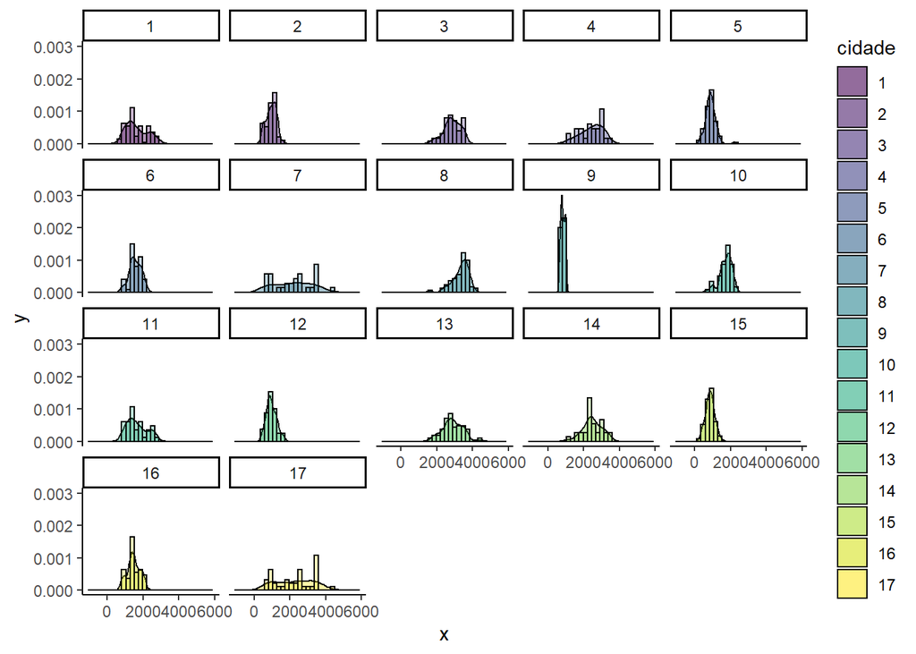

```r
vendas %>%
  group_by(cidade) %>%
  mutate(linhas = 1:n()) %>%
  mutate(x = unlist(density(receita, n = max(linhas))["x"]),
         y = unlist(density(receita, n = max(linhas))["y"])) %>%

  ggplot() +
  geom_area(aes(x = x, y = y, group = cidade, fill = cidade), color = "black", alpha = 0.4) +
  geom_histogram(aes(x = receita,
                     y = ..density..,
                     fill = cidade),
                 color = "black",
                 position = 'identity',
                 alpha = 0.3) +
  facet_wrap(~ cidade) +
  scale_fill_viridis_d() +
  scale_color_viridis_d() +
  theme_classic()
```

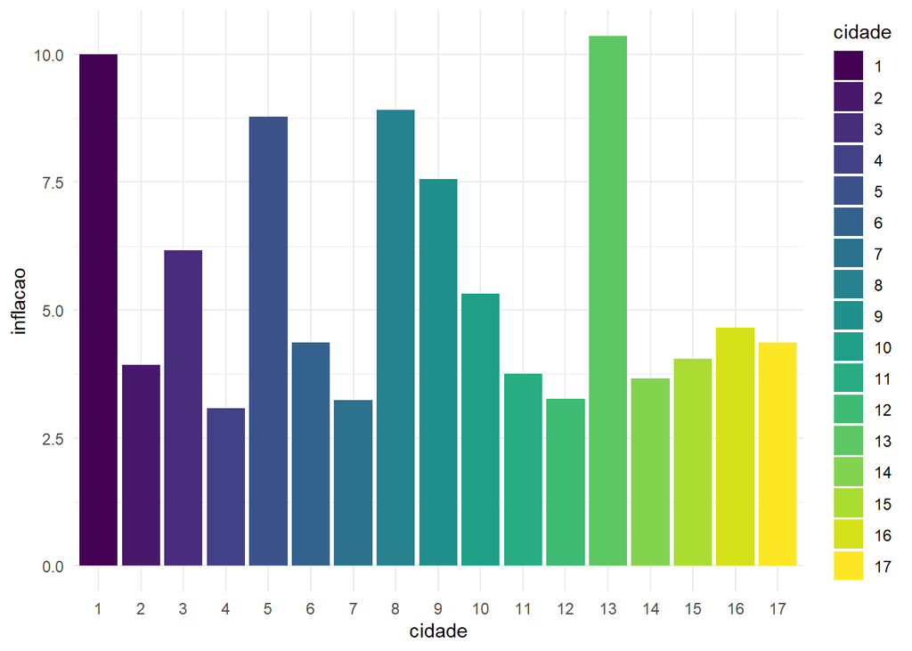

```r
vendas %>%
  ggplot() +
  geom_bar(aes(x = cidade, y=inflacao, fill = cidade), stat = "identity") +
  scale_y_continuous() +
  scale_fill_viridis_d() +
  theme_minimal()
```

Temos aqui os indícios necessário para iniciar a exploração de modelos de regressão!

## Criação dos modelos

Para a modelagem multinível utiliza-se a técnica **step-up** onde o modelo é otimizado a cada execução até obter-se sua versão final. Para verificar o modelo vamos utilizar o **BIC (bayesian information criterion)** critério que avalia o quão perto o modelo está dados reais considerando também as variáveis explicativas.

O primeiro modelo a ser criado é o **modelo nulo**, que não considera nenhuma variável preditora, apenas a receita e o agrupamento por cidade. Sua fórmula pode é:

$$receita_{ij} = \gamma_{00} + \nu_{0j} + \epsilon_{ij}$$

Onde:

- $\gamma_{00}$ representa a média geral da variável receita
- $\nu_{0j}$ representa a influência da cidade sobre a receita
- $\nu_{ij}$ representa a distância entre a receita calculada para aquela observação e o valor real

Observe que todos os dados são subscritos de com i e j onde i representa o dado no nível loja e j no nível cidade.

No R a execução desta fórmula é feita pelo comando `lme` do pacote `nlme`

```r
#fixed é a fórmula base, de regressão linear
#random é a fórmula de agrupamento dos dados, neste caso cidade
hlm_nulo =
  lme(fixed = receita ~1,
      random = ~1 | cidade,
      data = vendas,
      method = "REML")

BIC(hlm_nulo)
```

```
## [1] 14212.24
```

O BIC de nosso modelo base é 14212.24, ele será utilizado mais adiante para compararmos o ganho dos próximos modelos. Quando menor ele for, melhor!

```r
stderr_nlme(hlm_nulo)
```

```
##   RE.Components Variance.Estimatives  Std.Err.        z p.value
## 1      Var(v0j)             626248.2 223061.02  2.80752   0.005
## 2        Var(e)             254473.4  11949.33 21.29604   0.000
```

Outra informação importante vem através do método `stderr_nlme`, nele podemos ver que o p-value de nossa variável receita (v0j) é estatisticamente significativa (menor que 0,05), indicando que o modelo multinível é aplicável à este caso. Se ela fosse superior a 0,05 o modelo de regressão linear simples seria o mais indicado.

Utilizaremos agora a base de testes para executar nosso modelo e comparar se os resultados previstos estão próximos do resultado real.

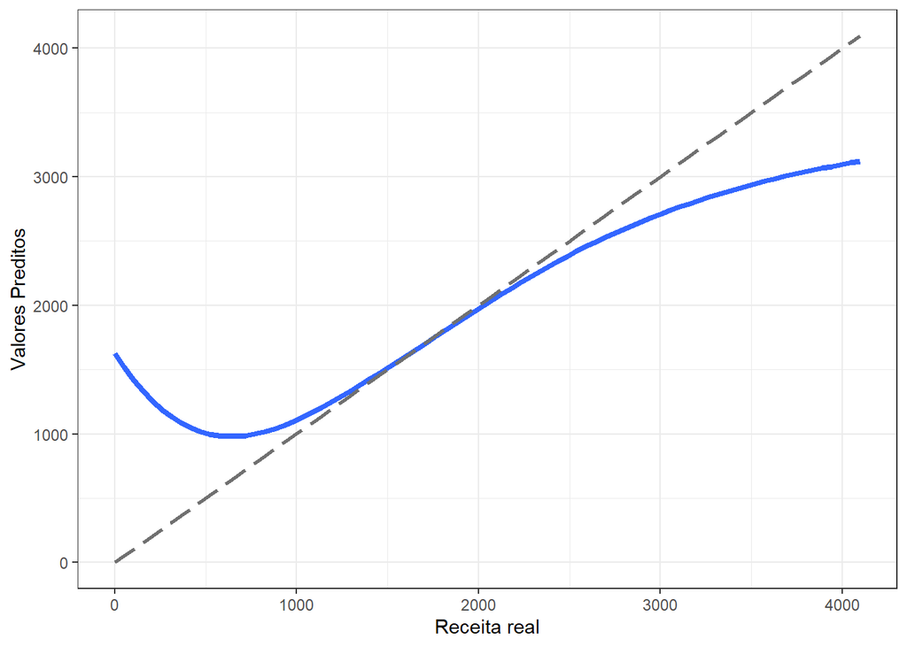

```r
teste$hlm_nulo_fitted = predict(hlm_nulo, teste)

teste %>%

  ggplot() +
  geom_smooth(aes(x = receita, y = hlm_nulo_fitted),
              method = "lm", se = F, formula = y ~ splines::bs(x, df = 5),
              size = 1.5) +
  geom_smooth(aes(x = receita, y = receita), method = "lm",
              color = "gray44", size = 1.05,
              linetype = "longdash") +
  labs(x = "Receita real", y = "Valores Preditos") +
  theme_bw()
```

Observe que a linha azul (modelo nulo) chega a tocar a linha pontilhada (resultado perfeito), mas apresenta considerável diferença no início e no final da reta.

### **Modelo com interceptos aleatórios**

O próximo passo, é a **modelo com interceptos aleatórios** que considera apenas efeito que a cidade (intercepto) exerce sobre a receita :

$$receita_{ij} = \gamma_{00} + \gamma_{10} * nps_{ij} + \nu_{0j} + \epsilon_{ij}$$

Onde:

- $\gamma_{00}$ representa a média geral da variável receita
- $\gamma_{10}$ representa a inclinação da reta de receita de acordo com o avanço do NPS
- $\nu_{0j}$ representa a influência da cidade sobre a receita
- $\nu_{ij}$ representa a distância entre a receita calculada para aquela observação e o valor real

No R a fórmula pode ser representada como no exemplo abaixo:

```r
hlm_intercept_aleatorios =
  lme(fixed = receita ~ nps  + inflacao,
      random = ~1 | cidade,
      data = vendas,
      method = "REML")

#observação do BIC do modelo
BIC(hlm_intercept_aleatorios)
```

```
## [1] 13421.34
```

| Modelo | BIC |
| --- | --- |
| Modelo Nulo | 14212.24 |
| *Modelo com interceptos aleatórios* | *13421,35* |

O indicador BIC, que no modelo nulo, é de 14212,24 foi reduzido para 13421,35 indicando que a variável NPS possui grande efeito sobre a receita.

```r
stderr_nlme(hlm_intercept_aleatorios)
```

```
##   RE.Components Variance.Estimatives  Std.Err.         z p.value
## 1      Var(v0j)             142365.8 52902.868  2.691079   0.007
## 2        Var(e)             110375.8  5185.945 21.283637   0.000
```

O *p-value* do nível v0j segue abaixo de 0,05 indicando que o modelo é estatisticamente significativo.

Vamos verificar agora como os modelos se aproximam do valor ideal:

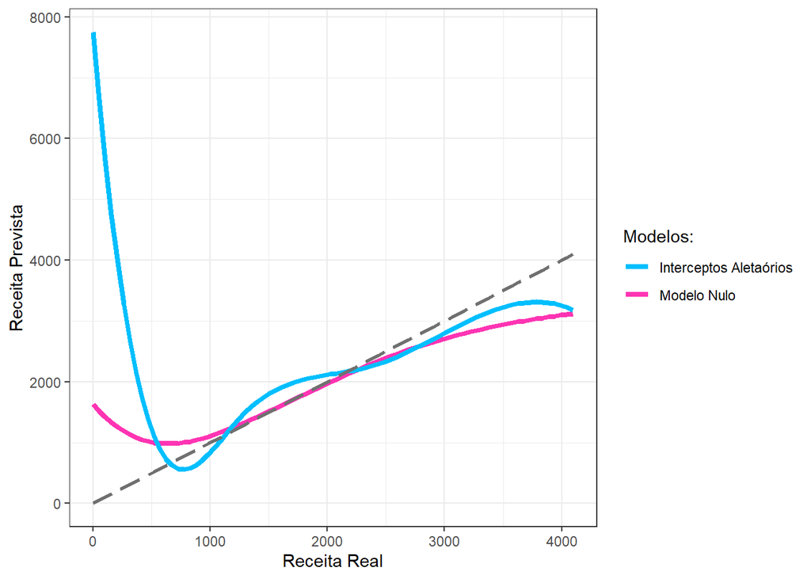

```r
teste$hlm_intercept_aleatorios_fitted = predict(hlm_intercept_aleatorios, teste)


teste %>%

  ggplot() +
  geom_smooth(aes(x = receita, y = hlm_nulo_fitted, color = "Modelo Nulo"),
              method = "lm", se = F, formula = y ~ splines::bs(x, df = 5),
              size = 1.5) +
  geom_smooth(aes(x = receita, y= hlm_intercept_aleatorios_fitted, color = "Interceptos Aletaórios"),
              method = "lm", se = F, formula = y ~ splines::bs(x, df = 5),
              size = 1.5) +

  geom_smooth(aes(x = receita, y = receita), method = "lm",
              color = "gray44", size = 1.05,
              linetype = "longdash") +
  scale_color_manual("Modelos:",
                     values = c("deepskyblue1", "maroon1")) +
  labs(x = "Receita Real", y = "Receita Prevista") +
  theme_bw()
```

### Modelo com interceptos e inclinações aleatórias

O próximo passo é verificarmos o efeito que a cidade exerce sobre o NPS e a receita e pode ser descrita pela função:

$$receita_{ij} = \gamma_{00} + \gamma_{10} * nps_{ij} + \nu_{0j} + \nu_{1j} * nps_{ij} + \epsilon_{ij}$$

Onde:

- $\gamma_{00}$ representa a média geral da variável receita
- $\gamma_{10}$ representa a inclinação da reta de receita de acordo com o avanço do NPS
- $\nu_{0j}$ representa a influência da cidade sobre a receita
- $\nu_{ij}$ representa a distância entre a receita calculada para aquela observação e o valor real

Observe que agora temos $\nu_{ij}$ influenciando o valor de NPS: $\nu_{ij} * nps_{ij}$

No R teremos:

```r
hlm_intercept_inclin =
  lme(fixed = receita ~ nps  + inflacao,
      random = ~ nps  | cidade,
      data = vendas,
      method = "REML")

BIC(hlm_intercept_inclin)
```

```
## [1] 13299.13
```

Nesta terceira execução observa-se uma nova queda no indicador BIC, mostrando que o volume de erros diminuiu em comparação com os modelos anteriores

| Modelo | BIC |
| --- | --- |
| Modelo Nulo | 14212 |
| Interceptos aleatórios | *13421* |
| *Interceptos e inclinações aleatórias* | *13299* |

```r
stderr_nlme(hlm_intercept_inclin)
```

```
##   Components Variance.Estimatives    Std.Err.        z p.value
## 1   Var(v0j)          658818.6994 302905.1560  2.17500   0.030
## 2   Var(v1j)             123.7548     47.6011  2.59983   0.009
## 3     Var(e)           90701.3200   4301.1633 21.08763   0.000
```

Por fim vamos comparar a performance dos modelos

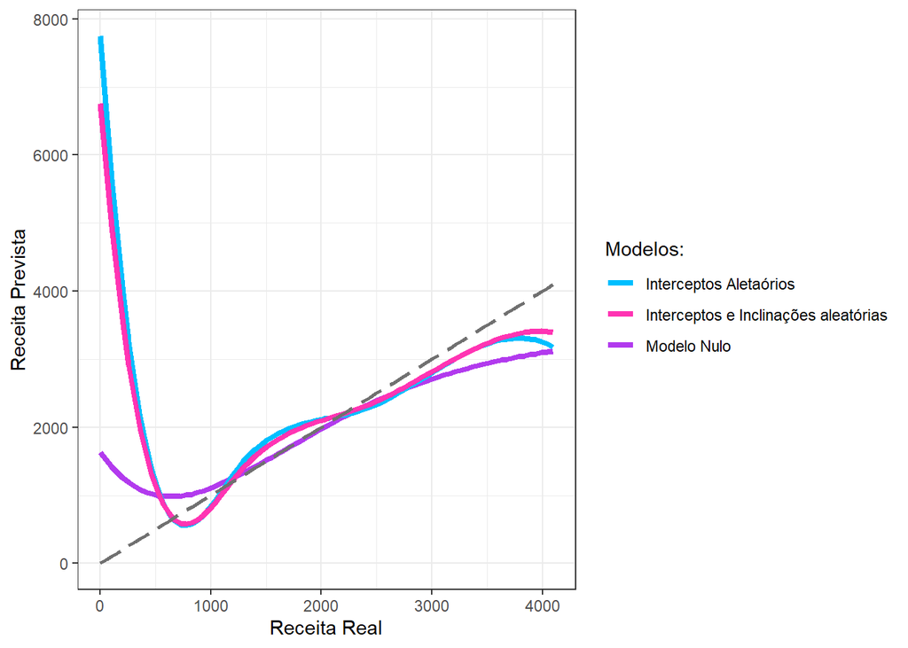

```r
teste$hlm_intercept_inclin_fitted = predict(hlm_intercept_inclin, teste)

teste %>%

  ggplot() +
  geom_smooth(aes(x = receita, y = hlm_nulo_fitted, color = "Modelo Nulo"),
              method = "lm", se = F, formula = y ~ splines::bs(x, df = 5),
              size = 1.5) +
  geom_smooth(aes(x = receita, y= hlm_intercept_aleatorios_fitted, color = "Interceptos Aletaórios"),
              method = "lm", se = F, formula = y ~ splines::bs(x, df = 5),
              size = 1.5) +

  geom_smooth(aes(x = receita, y= hlm_intercept_inclin_fitted, color = "Interceptos e Inclinações aleatórias"),
              method = "lm", se = F, formula = y ~ splines::bs(x, df = 5),
              size = 1.5) +

  geom_smooth(aes(x = receita, y = receita), method = "lm",
              color = "gray44", size = 1.05,
              linetype = "longdash") +
  scale_color_manual("Modelos:",
                     values = c("deepskyblue1", "maroon1", "darkorchid2")) +
  labs(x = "Receita Real", y = "Receita Prevista") +
  theme_bw()
```

### Modelo Final

Agora que verificamos que o NPS tem efeito sobre a receita e que o agrupamento por cidade também exerce efeito sobre as demais informações, vamos verificar se as variáveis do nível de cidade, neste caso a inflação local também impacta no resultado. Teremos finalmente a fórmula completa:

$$receita_{ij} = \gamma_{00} + \gamma_{10} * nps_{ij} + \gamma_{01} * inflacao_{j} + \gamma_{11} * nps_{ij} * inflacao_j + \nu_{0j} + \nu_{1j} * nps_{ij} + \epsilon_{ij}$$

No R teremos:

```r
hlm_final =
  lme(fixed = receita ~ nps  + inflacao + nps:inflacao,
      random = ~ nps | cidade,
      data = vendas,
      method = "REML")

BIC(hlm_final)
```

```
## [1] 13281.57
```

Observamos uma nova redução no BIC, indicando que o houve melhora no modelo ao incluir o efeito da inflação na receita e no NPS.

| Modelo | BIC |
| --- | --- |
| Modelo Nulo | 14212 |
| Interceptos aletórios | *13421* |
| Interceptos e inclinações aleatórias | 13299 |
| *Modelo Final* | *13281* |

```r
stderr_nlme(hlm_final)
```

```
##   Components Variance.Estimatives     Std.Err.         z p.value
## 1   Var(v0j)         392327.54923 163961.75910  2.392799   0.017
## 2   Var(v1j)             56.82155     24.49188  2.320016   0.020
## 3     Var(e)          90634.81776   4294.83656 21.103205   0.000
```

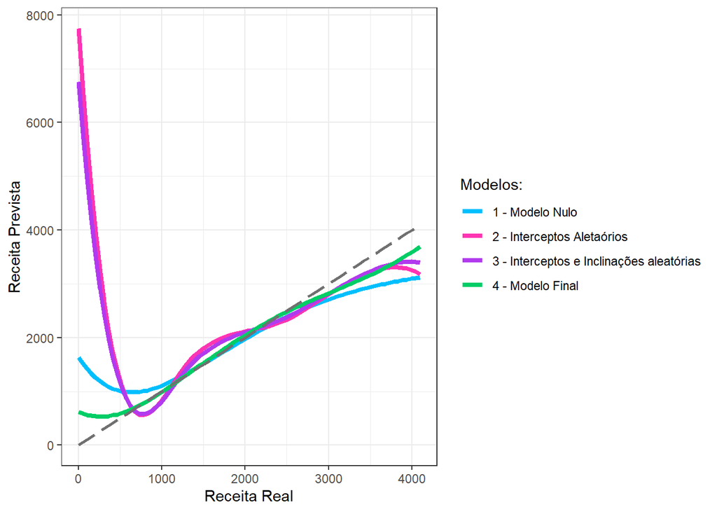

```r
teste$hlm_final_fitted = predict(hlm_final, teste)

teste %>%

  ggplot() +
  geom_smooth(aes(x = receita, y = hlm_nulo_fitted, color = "1 - Modelo Nulo"),
              method = "lm", se = F, formula = y ~ splines::bs(x, df = 5),
              size = 1.5) +
  geom_smooth(aes(x = receita, y= hlm_intercept_aleatorios_fitted, color = "2 - Interceptos Aletaórios"),
              method = "lm", se = F, formula = y ~ splines::bs(x, df = 5),
              size = 1.5) +

  geom_smooth(aes(x = receita, y= hlm_intercept_inclin_fitted, color = "3 - Interceptos e Inclinações aleatórias"),
              method = "lm", se = F, formula = y ~ splines::bs(x, df = 5),
              size = 1.5) +

  geom_smooth(aes(x = receita, y= hlm_final_fitted, color = "4 - Modelo Final"),
              method = "lm", se = F, formula = y ~ splines::bs(x, df = 5),
              size = 1.5) +

  geom_smooth(aes(x = receita, y = receita), method = "lm",
              color = "gray44", size = 1.05,
              linetype = "longdash") +
  scale_color_manual("Modelos:",
                     values = c("deepskyblue1", "maroon1", "darkorchid2", "SpringGreen3")) +
  labs(x = "Receita Real", y = "Receita Prevista") +
  theme_bw()
```

Ao compararmos as retas de regressão observamos que o modelo final (verde) performa melhor em comparação com todos os demais, ao considerar o efeito de todas as variáveis disponíveis.

### Bônus

Vamos comparar o modelo HLM com um modelo re regressão linar, utilizando todas as técnicas necessárias para aumentar sua acuracidade:

Sabendo que temos uma variável qualitativa (a cidade) utilizaremos o método `dummy_cols` para transformar as colunas de forma que possam ser utilizadas em uma regressão linar. A “dumização” transformará a coluna cidade em uma série de colunas (uma para cada cidade) preenchendo seu valor com 0 ou 1 dependendo do valor da coluna original

```r
vendas_dummies =
    dummy_cols(.data = vendas,
               select_columns = "cidade",
               remove_first_dummy = TRUE,
               remove_selected_columns = TRUE)

#16 colunas cidade foram criadas, o método dummy_cols não inclui a primeira coluna "dumizada" já que ela é a auzência de dados em todas as demais 16
```

Executamos o método `lm`para que seja criado o modelo de regressão simples, observe que agora cada coluna cidade deve ser informado na fórmula que seria:

$$Y = \gamma_0 + NPS_1 * \gamma_1 + inflacao * \gamma_2 + cidade_1 * \gamma_3 * cidade_2 * \gamma_4 + ... + cidade_n * \gamma_n + \epsilon$$

No R teremos a fórmula:

```r
ols_final_dummies =
  lm(formula = receita ~ nps + inflacao + cidade_2 + cidade_3 + cidade_4 + cidade_5 + cidade_6 + cidade_7 + cidade_8 + cidade_9 + cidade_10 + cidade_11 + cidade_12 +  cidade_13+ cidade_14+ cidade_15+ cidade_16+ cidade_17,
     data = vendas_dummies)
```

Ao criar variáveis *dummies* é necessário verificar se uma ou mais desta variáveis possuem significância estatística, para isso usamos o comando `summary`para verificar o *p-value* de cada um, toda variável com p-value maior que 0,05 deve ser removida do modelo

```r
summary(ols_final_dummies)
```

```
##
## Call:
## lm(formula = receita ~ nps + inflacao + cidade_2 + cidade_3 +
##     cidade_4 + cidade_5 + cidade_6 + cidade_7 + cidade_8 + cidade_9 +
##     cidade_10 + cidade_11 + cidade_12 + cidade_13 + cidade_14 +
##     cidade_15 + cidade_16 + cidade_17, data = vendas_dummies)
##
## Residuals:
##      Min       1Q   Median       3Q      Max
## -2514.31  -140.56     8.63   151.16  1333.93
##
## Coefficients: (1 not defined because of singularities)
##               Estimate Std. Error t value Pr(>|t|)
## (Intercept) -1.344e+04  1.083e+03 -12.412  < 2e-16 ***
## nps          2.852e+01  8.283e-01  34.426  < 2e-16 ***
## inflacao     1.270e+05  1.026e+04  12.377  < 2e-16 ***
## cidade_2     1.896e+01  1.102e+02   0.172   0.8634
## cidade_3    -9.563e+01  1.103e+02  -0.867   0.3862
## cidade_4    -4.043e+02  8.725e+01  -4.634 4.11e-06 ***
## cidade_5     3.096e+02  1.257e+02   2.464   0.0139 *
## cidade_6     6.555e+01  6.813e+01   0.962   0.3362
## cidade_7     2.746e+01  7.334e+01   0.374   0.7082
## cidade_8    -1.934e+03  2.371e+02  -8.157 1.14e-15 ***
## cidade_9     9.821e+02  2.005e+02   4.899 1.14e-06 ***
## cidade_10   -7.141e+02  5.836e+01 -12.236  < 2e-16 ***
## cidade_11   -1.409e+02  6.263e+01  -2.249   0.0247 *
## cidade_12    5.940e+01  1.118e+02   0.531   0.5954
## cidade_13   -1.421e+02  1.131e+02  -1.256   0.2093
## cidade_14   -9.191e+02  1.178e+02  -7.799 1.71e-14 ***
## cidade_15    1.874e+03  2.508e+02   7.470 1.89e-13 ***
## cidade_16    3.923e+02  8.171e+01   4.801 1.84e-06 ***
## cidade_17           NA         NA      NA       NA
## ---
## Signif. codes:  0 '***' 0.001 '**' 0.01 '*' 0.05 '.' 0.1 ' ' 1
##
## Residual standard error: 332.2 on 906 degrees of freedom
## Multiple R-squared:  0.8843, Adjusted R-squared:  0.8821
## F-statistic: 407.3 on 17 and 906 DF,  p-value: < 2.2e-16
```

Para fazer a remoção destas variáveis podemos utilizar o método *stepwise*, que fará a remoção e recalculará o modelo apenas com aquelas variáveis que possuem a capacidade de explicar o modelo

```r
ols_final_dummies_step =
  step(object = ols_final_dummies,
       step = qchisq(p = 0.05, df = 1,lower.tail = FALSE))
```

```
## Start:  AIC=10746.98
## receita ~ nps + inflacao + cidade_2 + cidade_3 + cidade_4 + cidade_5 +
##     cidade_6 + cidade_7 + cidade_8 + cidade_9 + cidade_10 + cidade_11 +
##     cidade_12 + cidade_13 + cidade_14 + cidade_15 + cidade_16 +
##     cidade_17
##
##
## Step:  AIC=10746.98
## receita ~ nps + inflacao + cidade_2 + cidade_3 + cidade_4 + cidade_5 +
##     cidade_6 + cidade_7 + cidade_8 + cidade_9 + cidade_10 + cidade_11 +
##     cidade_12 + cidade_13 + cidade_14 + cidade_15 + cidade_16
##
##             Df Sum of Sq       RSS   AIC
## - cidade_2   1      3270 100003054 10745
## - cidade_7   1     15473 100015257 10745
## - cidade_12  1     31152 100030936 10745
## - cidade_3   1     82951 100082735 10746
## - cidade_6   1    102172 100101956 10746
## - cidade_13  1    174243 100174027 10747
## <none>                    99999784 10747
## - cidade_11  1    558331 100558114 10750
## - cidade_5   1    669874 100669658 10751
## - cidade_4   1   2370248 102370031 10767
## - cidade_16  1   2544440 102544224 10768
## - cidade_9   1   2648615 102648399 10769
## - cidade_15  1   6158538 106158321 10800
## - cidade_14  1   6714231 106714015 10805
## - cidade_8   1   7343946 107343730 10810
## - cidade_10  1  16525380 116525163 10886
## - inflacao   1  16909397 116909180 10889
## - nps        1 130813027 230812811 11518
##
## Step:  AIC=10745.01
## receita ~ nps + inflacao + cidade_3 + cidade_4 + cidade_5 + cidade_6 +
##     cidade_7 + cidade_8 + cidade_9 + cidade_10 + cidade_11 +
##     cidade_12 + cidade_13 + cidade_14 + cidade_15 + cidade_16
##
##             Df Sum of Sq       RSS   AIC
## - cidade_7   1     20346 100023400 10743
## - cidade_12  1     41780 100044834 10743
```

[output cut: 28 more lines]

```
## - cidade_5   1   2230779 102254178 10762
## - cidade_4   1   3210063 103233463 10770
## - cidade_16  1   4734930 104758330 10784
## - cidade_9   1  10430538 110453938 10833
## - cidade_14  1  12824578 112847978 10853
## - cidade_10  1  18406072 118429472 10897
## - cidade_8   1  23029683 123053083 10933
## - cidade_15  1  23793717 123817117 10938
## - inflacao   1  67164122 167187522 11216
## - nps        1 130943242 230966641 11514
##
## Step:  AIC=10741.63
## receita ~ nps + inflacao + cidade_3 + cidade_4 + cidade_5 + cidade_6 +
##     cidade_8 + cidade_9 + cidade_10 + cidade_11 + cidade_13 +
##     cidade_14 + cidade_15 + cidade_16
```

```r
BIC(ols_final_dummies_step)
```

```
## [1] 13443.09
```

| Modelo | BIC |
| --- | --- |
| Modelo Nulo | 14212 |
| Interceptos aleatórios | 13421 |
| Interceptos e inclinações aleatórias | 13299 |
| *Modelo Final* | *13281* |
| OLS com apenas c/ variáveis significativas | 13443 |

Para finalizar vamos comparar o modelo final com o modelo OLS com variáveis *dummies* e *stepwise*:

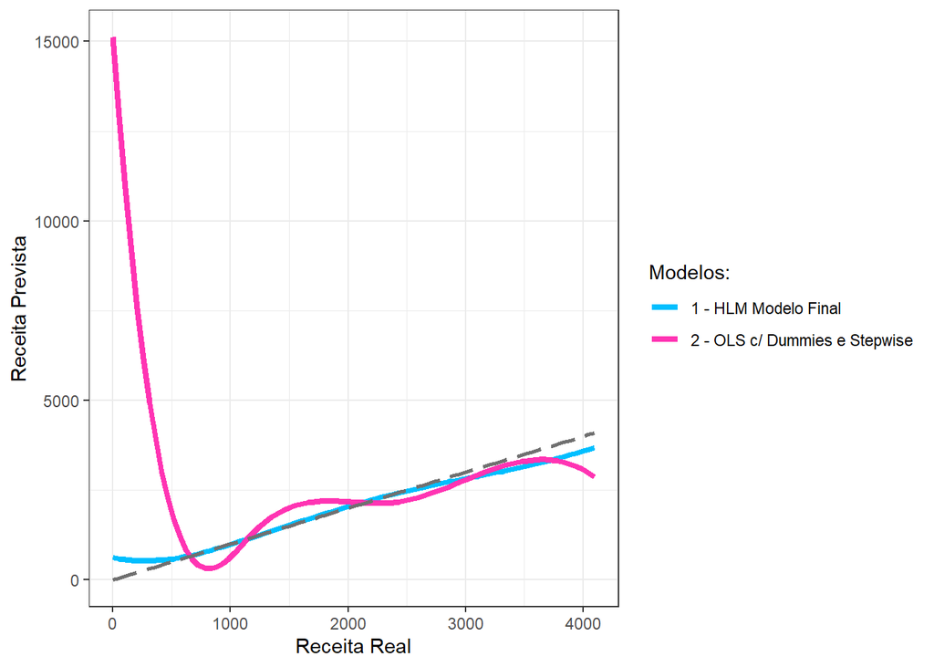

```r
teste_dummies =
    dummy_cols(.data = teste,
               select_columns = "cidade",
               remove_first_dummy = TRUE,
               remove_selected_columns = TRUE)

teste_dummies$cidade_2 = NULL
teste_dummies$cidade_7 = NULL
teste_dummies$cidade_12 = NULL
teste_dummies$cidade_17 = NULL

teste$ols_completo_fitted = predict(ols_final_dummies_step, teste_dummies)



teste %>%

  ggplot() +
  geom_smooth(aes(x = receita, y = hlm_final_fitted, color = "1 - HLM Modelo Final"),
              method = "lm", se = F, formula = y ~ splines::bs(x, df = 5),
              size = 1.5) +
  geom_smooth(aes(x = receita, y= ols_completo_fitted, color = "2 - OLS c/ Dummies e Stepwise"),
              method = "lm", se = F, formula = y ~ splines::bs(x, df = 5),
              size = 1.5) +


  geom_smooth(aes(x = receita, y = receita), method = "lm",
              color = "gray44", size = 1.05,
              linetype = "longdash") +
  scale_color_manual("Modelos:",
                     values = c("deepskyblue1", "maroon1")) +
  labs(x = "Receita Real", y = "Receita Prevista") +
  theme_bw()
```

### Conclusão

A regressão multinível é capaz de considerar melhor todas os aspectos dos dados de treino do modelo, criando um modelo capaz de prever com maior exatidão valores futuros.

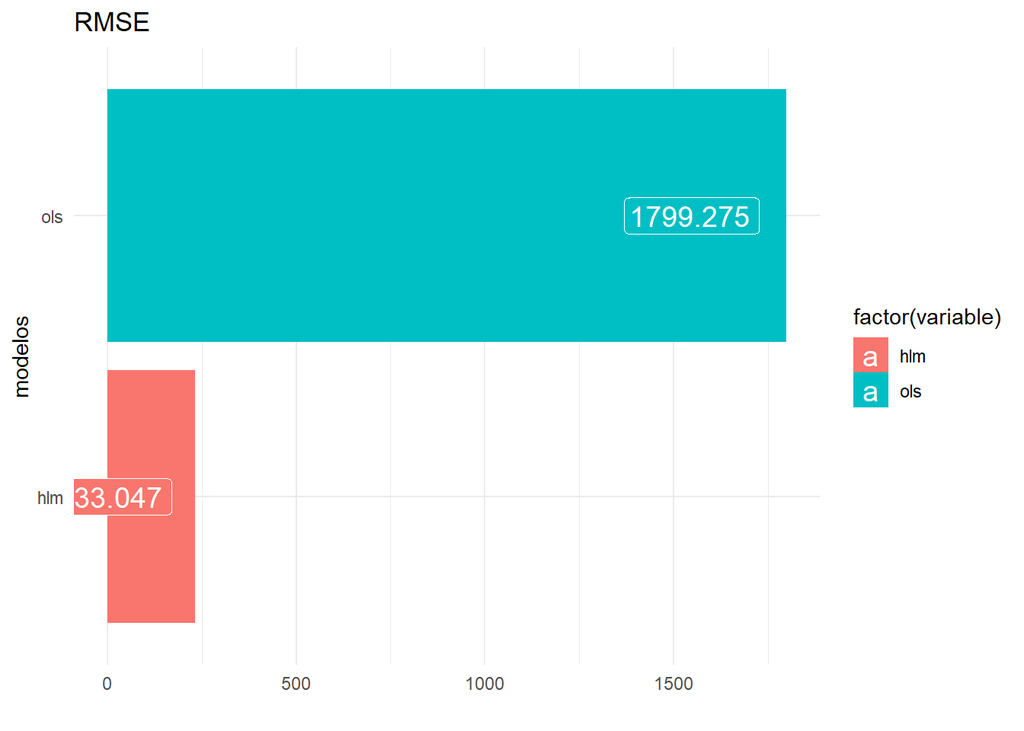

```r
teste %>%

  summarise(hlm = sqrt(mean((receita - hlm_final_fitted) ^ 2,na.rm = T)),
            ols = sqrt(mean((receita - ols_completo_fitted) ^ 2,na.rm = T))) %>%
  melt() %>%
  ggplot(aes(y = value, x=variable, fill = factor(variable))) +
  geom_bar(stat = "identity") +
  geom_label(aes(label = (round(value,3))), hjust = 1.2, color = "white", size = 5) +
  coord_flip() +
  labs(title="RMSE",
       x = "modelos",
       y = "") +
  theme_minimal()
```

Infelizmente desta vez eu não posso divulgar os dados originais, mas com este mesmo código, apenas substituindo as variáveis receita, NPS, inflação e cidade é possível aplicá-la a diversos cenários de dados.

Caso encontre alguma falha nos algoritmos ou um erro no processo, por favor me avise no meu linkedin (https://www.linkedin.com/in/marcosmhs/) e ficarei feliz realizar as correções necessárias e incluí-lo neste texto.

Até a próxima!